# UVOD U MACHINE LEARNING

## Upravljanje podacima: Uvod u Pandas i Numpy za ML

Feedback should be send to goran.milovanovic@datakolektiv.com.

[figure not shown]

### Lecturers

[Goran S. Milovanović, PhD, DataKolektiv, Chief Scientist & Owner](https://www.linkedin.com/in/gmilovanovic/)

[Aleksandar Cvetković, PhD, DataKolektiv, Consultant](https://www.linkedin.com/in/alegzndr/)

[Ilija Lazarević, MA, DataKolektiv, Consultant](https://www.linkedin.com/in/ilijalazarevic/)

[figure not shown]

## Pandas introduction

Pandas is a popular open-source data manipulation and analysis library in Python. It provides powerful tools and data structures for efficiently working with structured data, making it an essential framework for data scientists, analysts, and developers. With its intuitive syntax and extensive functionality, Pandas simplifies the process of data cleaning, transformation, exploration, and visualization.

At the core of the Pandas framework are two fundamental data structures: **Series** and **DataFrame**. A Series is a one-dimensional labeled array that can hold various data types, such as integers, floats, strings, or even Python objects. It is similar to a column in a spreadsheet or a single column of a table in a relational database. On the other hand, a DataFrame is a two-dimensional labeled data structure, consisting of rows and columns, which represents a tabular, spreadsheet-like structure. It is highly flexible and allows for the manipulation and analysis of structured data, including operations like filtering, sorting, merging, and grouping.

Pandas offers a wide range of functions and methods to perform common data operations effortlessly. It provides powerful tools for data cleaning, such as handling missing data, removing duplicates, and transforming data formats. Additionally, Pandas enables data exploration and analysis through functionalities like filtering and sorting data, statistical calculations, and handling time series data. It also seamlessly **integrates** with other popular Python libraries, such as **NumPy** for numerical computing and **Matplotlib** for data visualization, further enhancing its capabilities for data analysis and visualization tasks. Whether you are working with small or large datasets, Pandas provides efficient and scalable solutions for data manipulation and analysis in Python.

Before starting with Pandas and NumPy, let's import these libraries.

There are some standards that we shall abide here. It is more of a good practice, and you will see other engineers import these in the same way. Why is this good practice? You are used to these names, and once you import them, you just use them from then on.

```python
import numpy as np
import pandas as pd
```

### Creating structures

As already stated, at the core of the Pandas framework are two fundamental data structures: **Series** and **DataFrame**.

How does these look like?

```python
series_test1 = pd.Series([1,2,3,4,5])
```

```python
series_test1
```

```
0    1
1    2
2    3
3    4
4    5
dtype: int64
```

These two columns are:

- indices, and
- Series values.

Indices are more or less for the same reason as there are for Python lists. It is just that you can see them here for easier manipulation with your Series instance.

`dtype: int64` is the data type for your Series. For now, we will just say that your Series is of type *integer*, and that means it contains only integer values.

```python
series_test2 = pd.Series([1,2.2,3,4,5])
```

```python
series_test2
```

```
0    1.0
1    2.2
2    3.0
3    4.0
4    5.0
dtype: float64
```

Now, you can see `dtype: float64` and this means your Series contains float numbers only. But wait, we created it with `[1, 2.2, 3, 4, 5]`, where only one value was of type `float`. Well, since float numbers are superset of integer numbers, all of the values are converted to float.

What else do we have. Strings are valid values too.

```python
series_test3 = pd.Series(['marko', 'jovana', 'mirko', 'dragana'])
```

```python
series_test3
```

```
0      marko
1     jovana
2      mirko
3    dragana
dtype: object
```

This is perfectly valid instance of Series too. Working with strings in Pandas is just as usual as working with numbers. Pandas recognizes these strings as `objects`. But you can be explicit and do a conversion to string.

```python
series_test3 = series_test3.astype('string')

series_test3
```

```
0      marko
1     jovana
2      mirko
3    dragana
dtype: string
```

Now that we mentioned conversion, you can do this the same way with numbers too.

```python
series_test1
```

```
0    1
1    2
2    3
3    4
4    5
dtype: int64
```

```python
series_test1.astype('float')
```

```
0    1.0
1    2.0
2    3.0
3    4.0
4    5.0
dtype: float64
```

Or do the other way around.

```python
series_test2
```

```
0    1.0
1    2.2
2    3.0
3    4.0
4    5.0
dtype: float64
```

```python
series_test2.astype('int')
```

```
0    1
1    2
2    3
3    4
4    5
dtype: int64
```

Very easy.

And what about *DataFrame*, how can we create it?

Well, there are multiple ways to create it. Let's see couple of different ones.

```python
df_test1 = pd.DataFrame([1,2,3,4,5])
df_test1
```

|  | 0 |
| --- | --- |
| 0 | 1 |
| 1 | 2 |
| 2 | 3 |
| 3 | 4 |
| 4 | 5 |

Strangely, this looks almost like the Series object, but it is displayed a bit differently. We assure you, it is indeed different data structure.

Pandas DataFrame is like a tabular data structure. With rows and columns. Something you would see in databases or Excel sheets.

```python
df_test2 = pd.DataFrame([1,2,3,4,5], columns=['numbers'])
df_test2
```

|  | numbers |
| --- | --- |
| 0 | 1 |
| 1 | 2 |
| 2 | 3 |
| 3 | 4 |
| 4 | 5 |

Nice! You can name your columns. Can we add more columns?

```python
df_test3 = pd.DataFrame([[1, 'marko'],[2, 'jovana'], [3, 'mirko'], [4, 'dragana'], [5, 'nikola']], columns=['rank', 'name'])
df_test3
```

|  | rank | name |
| --- | --- | --- |
| 0 | 1 | marko |
| 1 | 2 | jovana |
| 2 | 3 | mirko |
| 3 | 4 | dragana |
| 4 | 5 | nikola |

Well, this is convenient. And yet, it can be very tiring to create DataFrame like this. Let's use Python to help us with it's functions.

```python
_ranks = list(range(5))
_names = ['marko', 'jovana', 'mirko', 'dragana', 'nikola']
_ocene = [4, 3, 2.5, 1, 2]

df_test3 = pd.DataFrame(list(zip(_ranks, _names, _ocene)), columns=['rank', 'name', 'grade'])

df_test3
```

|  | rank | name | grade |
| --- | --- | --- | --- |
| 0 | 0 | marko | 4.0 |
| 1 | 1 | jovana | 3.0 |
| 2 | 2 | mirko | 2.5 |
| 3 | 3 | dragana | 1.0 |
| 4 | 4 | nikola | 2.0 |

What did we do here? We used Python's `zip` and `list` functions to make it easier for us to create DataFrame.

How do these work?

```python
zip([1,2,3], [1,2,3])
```

```
<zip at 0x7f3654208e80>
```

```python
list(zip([1,2,3], [5,6,7]))
```

```
[(1, 5), (2, 6), (3, 7)]
```

`zip` pairs your lists so that each list's value at the same index goes into the same resulting tuple. If we have 2 lists with 3 values, the result will be 3 tuples, each with 2 values.

`list` is used to unwrap this from the `zip` response. `zip` is a *generator*, but disregard that for now. It is an advanced concept in Python.

Anyway, you can use these with more separate lists, like we did in our example. There we combined 3 lists with ranks, names and grades.

How else can we create DataFrame...

```python
_data = {
    'ranks': [1,2,3,4],
    'colors': ['red', 'blue', 'green', 'yellow'],
    'shape': ['square', 'circle', 'cloud', 'heart']
}

df_test4 = pd.DataFrame(_data)
```

```python
df_test4
```

|  | ranks | colors | shape |
| --- | --- | --- | --- |
| 0 | 1 | red | square |
| 1 | 2 | blue | circle |
| 2 | 3 | green | cloud |
| 3 | 4 | yellow | heart |

See how we do not have to name the columns explicitly. DataFrame recognizes that column names are coming from dictionary's keys.

One more way how we can create DataFrame:

```python
_data = {
    'rank': {0: 1, 1: 3, 2: 4, 4: 5},
    'name': {0: 'marko', 1: 'nikola', 2: 'jovana', 4: 'dragana'},
    'grade': {0: 4.3, 1: 2, 2: 5, 4: 4.5}
}

df_test5 = pd.DataFrame(_data)
```

```python
df_test5
```

|  | rank | name | grade |
| --- | --- | --- | --- |
| 0 | 1 | marko | 4.3 |
| 1 | 3 | nikola | 2.0 |
| 2 | 4 | jovana | 5.0 |
| 4 | 5 | dragana | 4.5 |

All good except the indices at the first 'column'. The one showing indices. We call it *index*. Values are not succesive numbers like before. We were able to define these too. More on this later.

### Getting to know your data structure

So far we have seen how Series and DataFrame are created. Now we will show how to play around with the data.

We will start with simple example and then use already existing dataset.

```python
df_test5
```

|  | rank | name | grade |
| --- | --- | --- | --- |
| 0 | 1 | marko | 4.3 |
| 1 | 3 | nikola | 2.0 |
| 2 | 4 | jovana | 5.0 |
| 4 | 5 | dragana | 4.5 |

As we said DataFrame is a data structure, somewhat similar to the tables you have seen in databases or even in Excel sheets. However, these are real objects in Python, and as objects have their attributes and methods. These objects contain certain state. Part of this state is the data these objects hold.

Let's go and see how we can interact with DataFrames and Series and what information do these objects contain beside the data that we see.

We can get detailed description of our DataFrame from the perspective of data types and memory used for storing it in memory.

```python
df_test5.info()
```

```
<class 'pandas.core.frame.DataFrame'>
Index: 4 entries, 0 to 4
Data columns (total 3 columns):
 #   Column  Non-Null Count  Dtype
---  ------  --------------  -----
 0   rank    4 non-null      int64
 1   name    4 non-null      object
 2   grade   4 non-null      float64
dtypes: float64(1), int64(1), object(1)
memory usage: 128.0+ bytes
```

From this overview we can see:

- number of rows (4),
- number of columns (3),
- names of columns,
- data type for each column
- memory usage for this data frame (kind of*).

Kind of is just a note to know that this may not show real memory footprint, but we will not go into details about this on this course.

Next, we can access parts of this overview in the following ways.

How about we can dimensions of our DataFrame. When we say dimensions, you can view our table as a matrix, which it is, in essence, and then dimensions are number of rows and columns of that matrix.

```python
df_test5.shape
```

```
(4, 3)
```

Or get names of columns...

```python
df_test5.columns
```

```
Index(['rank', 'name', 'grade'], dtype='object')
```

Disregard this `Index` object at this point. It is just another data structure and we can use it as the list.

Example:

```python
df_test5.columns[0]
```

```
'rank'
```

Then, we can get the indices for each row. Again, it's one subtype of `Index` class, but for integers now.

```python
df_test5.index
```

```
Index([0, 1, 2, 4], dtype='int64')
```

We can go and select specific columns like this:

```python
df_test5[['name']]
```

|  | name |
| --- | --- |
| 0 | marko |
| 1 | nikola |
| 2 | jovana |
| 4 | dragana |

```python
df_test5[['name', 'rank']]
```

|  | name | rank |
| --- | --- | --- |
| 0 | marko | 1 |
| 1 | nikola | 3 |
| 2 | jovana | 4 |
| 4 | dragana | 5 |

```python
df_test5['name']
```

```
0      marko
1     nikola
2     jovana
4    dragana
Name: name, dtype: object
```

So, what is the difference with last example? Well, if you use `df_test5[['name']]` then you select that column but the result is DataFrame.

On the other side, if you select column with `df_test5['name']` then you get the Pandas Series.

```python
type(df_test5['name'])
```

```
pandas.core.series.Series
```

Next, let's see how we can check th e data types of columns.

```python
df_test5.dtypes
```

```
rank       int64
name      object
grade    float64
dtype: object
```

In real life you will have multiple columns of the same type, but different groups in general. Then, you will want to select specific data types. Here is how you do it:

```python
df_test5.select_dtypes(include='object')
```

|  | name |
| --- | --- |
| 0 | marko |
| 1 | nikola |
| 2 | jovana |
| 4 | dragana |

```python
df_test5.select_dtypes(exclude='object')
```

|  | rank | grade |
| --- | --- | --- |
| 0 | 1 | 4.3 |
| 1 | 3 | 2.0 |
| 2 | 4 | 5.0 |
| 4 | 5 | 4.5 |

```python
df_test5.select_dtypes(include='integer')
```

|  | rank |
| --- | --- |
| 0 | 1 |
| 1 | 3 |
| 2 | 4 |
| 4 | 5 |

### Basic data manipulation

And what about selecting rows?

In Pandas there are two most popular approaches in how you explicitly select rows. By using `log` and `iloc`.

Let's try them out and then explain how each works.

Remember, **indexing in Python starts at 0 and so does in Pandas**!!

```python
# refresher
df_test5
```

|  | rank | name | grade |
| --- | --- | --- | --- |
| 0 | 1 | marko | 4.3 |
| 1 | 3 | nikola | 2.0 |
| 2 | 4 | jovana | 5.0 |
| 4 | 5 | dragana | 4.5 |

```python
df_test5.loc[0]
```

```
rank         1
name     marko
grade      4.3
Name: 0, dtype: object
```

```python
df_test5.loc[2]
```

```
rank          4
name     jovana
grade       5.0
Name: 2, dtype: object
```

```python
# This wont work
# df_test5.loc[3]
```

```python
df_test5.loc[4]
```

```
rank           5
name     dragana
grade        4.5
Name: 4, dtype: object
```

This makes sense having in mind previous explanation.

But what if you want to select multiple rows, in a range of values.

```python
df_test5.loc[2: 4]
```

|  | rank | name | grade |
| --- | --- | --- | --- |
| 2 | 4 | jovana | 5.0 |
| 4 | 5 | dragana | 4.5 |

Again, this is Python and this works in Pythonic way.

How about `iloc`? Well, `iloc` works by getting the positional index of the row. It disregards the values in indices. This means that our DataFrame can be queried in next way:

```python
# refresher
df_test5
```

|  | rank | name | grade |
| --- | --- | --- | --- |
| 0 | 1 | marko | 4.3 |
| 1 | 3 | nikola | 2.0 |
| 2 | 4 | jovana | 5.0 |
| 4 | 5 | dragana | 4.5 |

```python
df_test5.iloc[0]
```

```
rank         1
name     marko
grade      4.3
Name: 0, dtype: object
```

```python
df_test5.iloc[3]
```

```
rank           5
name     dragana
grade        4.5
Name: 4, dtype: object
```

Or you can do it specifying the range of values, just like you would do with Python lists.

```python
df_test5.iloc[0: 2]
```

|  | rank | name | grade |
| --- | --- | --- | --- |
| 0 | 1 | marko | 4.3 |
| 1 | 3 | nikola | 2.0 |

And now, how about we use `loc` and `iloc` to subset our DataFrame along the rows and columns axes.

```python
# refresher
df_test5
```

|  | rank | name | grade |
| --- | --- | --- | --- |
| 0 | 1 | marko | 4.3 |
| 1 | 3 | nikola | 2.0 |
| 2 | 4 | jovana | 5.0 |
| 4 | 5 | dragana | 4.5 |

```python
df_test5.loc[[0, 4], ['name', 'grade']]
```

|  | name | grade |
| --- | --- | --- |
| 0 | marko | 4.3 |
| 4 | dragana | 4.5 |

Hmm, we have used another way of selecting rows. Good. Now you know another alternative.

Important thing to note here is what happens in `df_test5.loc[ ... , ...]` part:

- First `...` is oriented toward rows in data frame and selecting them.
- Second `...` is oriented toward columns and selecting them. This works the same way with `iloc`.

One thing to remember is that `loc` slices based on labels. Labels of row index values and labels (names) of columns.

`iloc` on the other side uses just positional index values.

```python
# refresher
df_test5
```

|  | rank | name | grade |
| --- | --- | --- | --- |
| 0 | 1 | marko | 4.3 |
| 1 | 3 | nikola | 2.0 |
| 2 | 4 | jovana | 5.0 |
| 4 | 5 | dragana | 4.5 |

```python
df_test5.iloc[[0, 2, 3], [0]]
```

|  | rank |
| --- | --- |
| 0 | 1 |
| 2 | 4 |
| 4 | 5 |

```python
df_test5.iloc[[1, 3], [1, 2]]
```

|  | name | grade |
| --- | --- | --- |
| 1 | nikola | 2.0 |
| 4 | dragana | 4.5 |

This difference between `iloc` and `loc` will be a lot clearer now. We will introduce one interesting way of altering your tabular data. Namely, changing the index.

```python
df_test5.index
```

```
Index([0, 1, 2, 4], dtype='int64')
```

```python
df_test6 = df_test5.set_index('name')

df_test6
```

| name | rank | grade |
| --- | --- | --- |
| marko | 1 | 4.3 |
| nikola | 3 | 2.0 |
| jovana | 4 | 5.0 |
| dragana | 5 | 4.5 |

How do we go about using `loc` and `iloc` now?

```python
df_test6.loc['marko']
```

```
rank     1.0
grade    4.3
Name: marko, dtype: float64
```

```python
df_test6.loc[['marko']]
```

| name | rank | grade |
| --- | --- | --- |
| marko | 1 | 4.3 |

```python
df_test6.loc[['marko', 'jovana']]
```

| name | rank | grade |
| --- | --- | --- |
| marko | 1 | 4.3 |
| jovana | 4 | 5.0 |

```python
df_test6.loc[['marko', 'jovana'], ['grade']]
```

| name | grade |
| --- | --- |
| marko | 4.3 |
| jovana | 5.0 |

And what about `iloc`?

```python
#refresher
df_test6
```

| name | rank | grade |
| --- | --- | --- |
| marko | 1 | 4.3 |
| nikola | 3 | 2.0 |
| jovana | 4 | 5.0 |
| dragana | 5 | 4.5 |

```python
df_test6.iloc[[0, 2]]
```

| name | rank | grade |
| --- | --- | --- |
| marko | 1 | 4.3 |
| jovana | 4 | 5.0 |

It should be a lot clearer now.

Alright. Before we go further, we want to show you another way you can select your rows. It is called filtering and is based on logical condition.

A quick refresher on logical conditions. You write them when you writhe `if elif else` blocks of code. You you use them for `while` loops. You can use them for list and dictionary comprehensions.

Examples:

- `a == 5`
- `b <= 10`
- `c < 3 or c > 10`
- `d == 'start'`, etc.

How we can use them with DataFrame and Series? Well, when you use `loc` you can specify these conditions for selecting specific rows or columns.

```python
#refresher
df_test5
```

|  | rank | name | grade |
| --- | --- | --- | --- |
| 0 | 1 | marko | 4.3 |
| 1 | 3 | nikola | 2.0 |
| 2 | 4 | jovana | 5.0 |
| 4 | 5 | dragana | 4.5 |

Let's write one logical condition:

```python
df_test5['rank'] > 2
```

```
0    False
1     True
2     True
4     True
Name: rank, dtype: bool
```

This condition returns Pandas Series, albeit one of boolean values. Each value reprents logical condition evaluated on each row.

And now when we use this boolean Series, Pandas knows which row to select and return; the one where value was `True`.

```python
df_test5.loc[df_test5['rank'] > 2]
```

|  | rank | name | grade |
| --- | --- | --- | --- |
| 1 | 3 | nikola | 2.0 |
| 2 | 4 | jovana | 5.0 |
| 4 | 5 | dragana | 4.5 |

Or you can negate your condition and return opposite:

```python
df_test5.loc[~(df_test5['rank'] > 2)]
```

|  | rank | name | grade |
| --- | --- | --- | --- |
| 0 | 1 | marko | 4.3 |

Let's write another condition. This time to select based on `name` column values. Since we are dealing with object (string) column there is no sense to use numerical comparisons. So we will use two simple ways to form conditions.

```python
df_test5['name'] == 'jovana'
```

```
0    False
1    False
2     True
4    False
Name: name, dtype: bool
```

```python
df_test5.loc[df_test5['name'] == 'jovana']
```

|  | rank | name | grade |
| --- | --- | --- | --- |
| 2 | 4 | jovana | 5.0 |

Or, we can do it in more convenient way if there are multiple values to compare to.

```python
df_test5.loc[df_test5['name'].isin(['nikola', 'jovana'])]
```

|  | rank | name | grade |
| --- | --- | --- | --- |
| 1 | 3 | nikola | 2.0 |
| 2 | 4 | jovana | 5.0 |

Of course `isin` method is not strictly defined for string types. You can use it with numerical ones too.

```python
df_test5.loc[df_test5['rank'].isin([1, 2, 3, 6, 12, 23])]
```

|  | rank | name | grade |
| --- | --- | --- | --- |
| 0 | 1 | marko | 4.3 |
| 1 | 3 | nikola | 2.0 |

And if you combine these you can get a lot of freedom in slicing/selecting/filtering your data:

```python
_condition1 = df_test5['rank'].isin([1, 2, 3, 6, 12, 23])
_condition2 = df_test5['name'].isin(['marko', 'janko', 'jovan', 'dragana'])
_condition3 = df_test5['grade'] > 2

df_test5.loc[_condition1 & _condition2 & _condition3, ['rank', 'name']]
```

|  | rank | name |
| --- | --- | --- |
| 0 | 1 | marko |

And although picking columns and rows is interesting, we will move to other Pandas functionalities and leave other ways for you to discover.

### Altering your data

Working with your data in Pandas is half subsetting and half altering your data.

You have to be able to change values, parse them, update them, fill in missing values that may appear and so on.

Here are some ways you can alter your data.

```python
#refresher
df_test5
```

|  | rank | name | grade |
| --- | --- | --- | --- |
| 0 | 1 | marko | 4.3 |
| 1 | 3 | nikola | 2.0 |
| 2 | 4 | jovana | 5.0 |
| 4 | 5 | dragana | 4.5 |

```python
df_test5['rank'] * 5
```

```
0     5
1    15
2    20
4    25
Name: rank, dtype: int64
```

Here, you get the Series as the results, but with values 5 times then the original ones.

```python
df_test5['rank'] + 4/3
```

```
0    2.333333
1    4.333333
2    5.333333
4    6.333333
Name: rank, dtype: float64
```

It really is up to you to decide how you want to alter (transform) your data.

After your are done, you can alter your column values or add new column.

```python
df_test5['rank_transform'] = df_test5['rank'] + 5

df_test5
```

|  | rank | name | grade | rank_transform |
| --- | --- | --- | --- | --- |
| 0 | 1 | marko | 4.3 | 6 |
| 1 | 3 | nikola | 2.0 | 8 |
| 2 | 4 | jovana | 5.0 | 9 |
| 4 | 5 | dragana | 4.5 | 10 |

```python
df_test5['grade'] = df_test5['grade'] / 2

df_test5
```

|  | rank | name | grade | rank_transform |
| --- | --- | --- | --- | --- |
| 0 | 1 | marko | 2.15 | 6 |
| 1 | 3 | nikola | 1.00 | 8 |
| 2 | 4 | jovana | 2.50 | 9 |
| 4 | 5 | dragana | 2.25 | 10 |

Pay attention. Once you alter your column, you have lost previous values. Be careful.

You can alter your string typed columns too. But, you have to do it by telling Pandas that you want to access these values as strings, with `.str` attribute.

```python
df_test5['name'].str.capitalize()
```

```
0      Marko
1     Nikola
2     Jovana
4    Dragana
Name: name, dtype: object
```

```python
df_test5['name_caps'] = df_test5['name'].str.upper()
```

```python
df_test5
```

|  | rank | name | grade | rank_transform | name_caps |
| --- | --- | --- | --- | --- | --- |
| 0 | 1 | marko | 2.15 | 6 | MARKO |
| 1 | 3 | nikola | 1.00 | 8 | NIKOLA |
| 2 | 4 | jovana | 2.50 | 9 | JOVANA |
| 4 | 5 | dragana | 2.25 | 10 | DRAGANA |

There is really numerous ways of achieving the same result when working with Pandas. What may bother some of you is this imerative way of writing code, where you have to write multiple lines asigning values to each intermediary variable, before you get the DataFrame you need.

Fear not, Pandas provides another way of working with DataFrame, and it is pipelining. In a sense you chain methods and write one long line of code.

Example:

```python
#refresher
df_test5
```

|  | rank | name | grade | rank_transform | name_caps |
| --- | --- | --- | --- | --- | --- |
| 0 | 1 | marko | 2.15 | 6 | MARKO |
| 1 | 3 | nikola | 1.00 | 8 | NIKOLA |
| 2 | 4 | jovana | 2.50 | 9 | JOVANA |
| 4 | 5 | dragana | 2.25 | 10 | DRAGANA |

```python
df_test5.loc[df_test5['rank'] > 2, ['rank', 'name', 'grade']]
```

|  | rank | name | grade |
| --- | --- | --- | --- |
| 1 | 3 | nikola | 1.00 |
| 2 | 4 | jovana | 2.50 |
| 4 | 5 | dragana | 2.25 |

```python
df_test5.loc[df_test5['rank'] > 2, ['rank', 'name', 'grade']]\
        .assign(name_caps = lambda x: x['name'].str.upper(),
                new_grade = lambda x: x['grade'] * 10)
```

|  | rank | name | grade | name_caps | new_grade |
| --- | --- | --- | --- | --- | --- |
| 1 | 3 | nikola | 1.00 | NIKOLA | 10.0 |
| 2 | 4 | jovana | 2.50 | JOVANA | 25.0 |
| 4 | 5 | dragana | 2.25 | DRAGANA | 22.5 |

```python
df_test5.loc[df_test5['rank'] > 2, ['rank', 'name', 'grade']]\
        .assign(name_caps = lambda x: x['name'].str.upper(),
                new_grade = lambda x: x['grade'] * 10)\
        .drop(columns=['name', 'grade'])
```

|  | rank | name_caps | new_grade |
| --- | --- | --- | --- |
| 1 | 3 | NIKOLA | 10.0 |
| 2 | 4 | JOVANA | 25.0 |
| 4 | 5 | DRAGANA | 22.5 |

Here, you put all of your datawrangling power in one place, slice and alter your data to get the resulting DataFrame that you need.

One thing that we did introduce here for the purposes of previous example is `lambda` function.

For those who are not informed, `lambda` functions are unnamed or anonymous functions. This means these do not have their name like the functions you define with `def`. Also, these are restricted with functionalities they can provide and are used as oneliners for scenarios where you need some simple arithmetic operation or logical condition. `Lambda` functions are perfect for functional programming where whole pipeline is divided between numerous steps (lambda functions) that do one specific and small part of data set alteration.

This way of writing Panda code is handy and convenient and you easily can read it and get the picture of what is happening.

Now, since you have some basic skills in Pandas, let's use one reall dataset and see some data wrangling skills.

### Real dataset wrangling

Pandas being popular and widely used library for data manipulation has multiple ways of importing data. This data can come from file formats like CSV, JSON, XML, or you can connect to any relational and non-relational database and run query to get the data.

In our example we are going to work with **downsampled** [nycflights13 dataset](https://github.com/tidyverse/nycflights13). The data in `nycflights13` were originaly provided in an R package; we have extracted all tables present to CSV files and placed them in our `_data` directory to play with. It consists of data about flights that departed all airports in NYC in 2013.

The dataset we are going to use today is just the part of the original one.

```python
df_flights = pd.read_csv('_data/flights_session06.csv', index_col=0)

df_flights.head()
```

|  | Unnamed: 0 | year | month | day | dep_time | sched_dep_time | dep_delay | arr_time | sched_arr_time | arr_delay | carrier | flight | tailnum | origin | dest | air_time | distance | hour | minute | time_hour |
| --- | --- | --- | --- | --- | --- | --- | --- | --- | --- | --- | --- | --- | --- | --- | --- | --- | --- | --- | --- | --- |
| 23583 | 23583 | 2013 | 1 | 28 | 858.0 | 905 | -7.0 | 1004.0 | 1023 | -19.0 | JetBlue Airways | 56 | N323JB | John F Kennedy Intl | Burlington Intl | 48.0 | 266 | 9 | 5 | 2013-01-28 09:00:00 |
| 39402 | 39402 | 2013 | 10 | 14 | 1138.0 | 1130 | 8.0 | 1334.0 | 1338 | -4.0 | ExpressJet Airlines Inc. | 4445 | N21197 | Newark Liberty Intl | Indianapolis Intl | 94.0 | 645 | 11 | 30 | 2013-10-14 11:00:00 |
| 234025 | 234025 | 2013 | 6 | 13 | 1753.0 | 1455 | 178.0 | NaN | 1611 | NaN | Endeavor Air Inc. | 4280 | N8646A | John F Kennedy Intl | Philadelphia Intl | NaN | 94 | 14 | 55 | 2013-06-13 14:00:00 |
| 9240 | 9240 | 2013 | 1 | 11 | 1248.0 | 1300 | -12.0 | 1438.0 | 1450 | -12.0 | Envoy Air | 4426 | N713MQ | La Guardia | Port Columbus Intl | 83.0 | 479 | 13 | 0 | 2013-01-11 13:00:00 |
| 231428 | 231428 | 2013 | 6 | 11 | 557.0 | 605 | -8.0 | 731.0 | 749 | -18.0 | Delta Air Lines Inc. | 1279 | N358NB | La Guardia | Memphis Intl | 131.0 | 963 | 6 | 5 | 2013-06-11 06:00:00 |

```python
df_flights.head(4)
```

|  | Unnamed: 0 | year | month | day | dep_time | sched_dep_time | dep_delay | arr_time | sched_arr_time | arr_delay | carrier | flight | tailnum | origin | dest | air_time | distance | hour | minute | time_hour |
| --- | --- | --- | --- | --- | --- | --- | --- | --- | --- | --- | --- | --- | --- | --- | --- | --- | --- | --- | --- | --- |
| 23583 | 23583 | 2013 | 1 | 28 | 858.0 | 905 | -7.0 | 1004.0 | 1023 | -19.0 | JetBlue Airways | 56 | N323JB | John F Kennedy Intl | Burlington Intl | 48.0 | 266 | 9 | 5 | 2013-01-28 09:00:00 |
| 39402 | 39402 | 2013 | 10 | 14 | 1138.0 | 1130 | 8.0 | 1334.0 | 1338 | -4.0 | ExpressJet Airlines Inc. | 4445 | N21197 | Newark Liberty Intl | Indianapolis Intl | 94.0 | 645 | 11 | 30 | 2013-10-14 11:00:00 |
| 234025 | 234025 | 2013 | 6 | 13 | 1753.0 | 1455 | 178.0 | NaN | 1611 | NaN | Endeavor Air Inc. | 4280 | N8646A | John F Kennedy Intl | Philadelphia Intl | NaN | 94 | 14 | 55 | 2013-06-13 14:00:00 |
| 9240 | 9240 | 2013 | 1 | 11 | 1248.0 | 1300 | -12.0 | 1438.0 | 1450 | -12.0 | Envoy Air | 4426 | N713MQ | La Guardia | Port Columbus Intl | 83.0 | 479 | 13 | 0 | 2013-01-11 13:00:00 |

Let's check some basic info about our dataset.

```python
df_flights.info()
```

```
<class 'pandas.core.frame.DataFrame'>
Index: 33677 entries, 23583 to 26732
Data columns (total 20 columns):
 #   Column          Non-Null Count  Dtype
---  ------          --------------  -----
 0   Unnamed: 0      33677 non-null  int64
 1   year            33677 non-null  int64
 2   month           33677 non-null  int64
 3   day             33677 non-null  int64
 4   dep_time        32847 non-null  float64
 5   sched_dep_time  33677 non-null  int64
 6   dep_delay       32847 non-null  float64
 7   arr_time        32802 non-null  float64
 8   sched_arr_time  33677 non-null  int64
 9   arr_delay       32720 non-null  float64
 10  carrier         33677 non-null  object
 11  flight          33677 non-null  int64
 12  tailnum         33434 non-null  object
 13  origin          33677 non-null  object
 14  dest            33677 non-null  object
 15  air_time        32720 non-null  float64
 16  distance        33677 non-null  int64
 17  hour            33677 non-null  int64
 18  minute          33677 non-null  int64
 19  time_hour       33677 non-null  object
dtypes: float64(5), int64(10), object(5)
memory usage: 5.4+ MB
```

There is a lot of columns, and columns have 3 different data types: `int64`, `float64` and `object`. There is this column named `time_hour` that looks like a date with time.

We will use some of our previously acquired knowledge and get some details of this DataFrame.

```python
df_flights.columns
```

```
Index(['Unnamed: 0', 'year', 'month', 'day', 'dep_time', 'sched_dep_time',
       'dep_delay', 'arr_time', 'sched_arr_time', 'arr_delay', 'carrier',
       'flight', 'tailnum', 'origin', 'dest', 'air_time', 'distance', 'hour',
       'minute', 'time_hour'],
      dtype='object')
```

```python
df_flights.shape
```

```
(33677, 20)
```

We have over 30k flights. If you think this is too much, wait until you get real datasets. This one is for playing around.

```python
df_flights.dtypes
```

```
Unnamed: 0          int64
year                int64
month               int64
day                 int64
dep_time          float64
sched_dep_time      int64
dep_delay         float64
arr_time          float64
sched_arr_time      int64
arr_delay         float64
carrier            object
flight              int64
tailnum            object
origin             object
dest               object
air_time          float64
distance            int64
hour                int64
minute              int64
time_hour          object
dtype: object
```

Can we filter our columns based on their type so we can get overview of our data easily?

```python
df_flights.select_dtypes(include='object')
```

|  | carrier | tailnum | origin | dest | time_hour |
| --- | --- | --- | --- | --- | --- |
| 23583 | JetBlue Airways | N323JB | John F Kennedy Intl | Burlington Intl | 2013-01-28 09:00:00 |
| 39402 | ExpressJet Airlines Inc. | N21197 | Newark Liberty Intl | Indianapolis Intl | 2013-10-14 11:00:00 |
| 234025 | Endeavor Air Inc. | N8646A | John F Kennedy Intl | Philadelphia Intl | 2013-06-13 14:00:00 |
| 9240 | Envoy Air | N713MQ | La Guardia | Port Columbus Intl | 2013-01-11 13:00:00 |
| 231428 | Delta Air Lines Inc. | N358NB | La Guardia | Memphis Intl | 2013-06-11 06:00:00 |
| ... | ... | ... | ... | ... | ... |
| 255024 | JetBlue Airways | N591JB | La Guardia | Tampa Intl | 2013-07-06 07:00:00 |
| 216054 | United Air Lines Inc. | N416UA | Newark Liberty Intl | Seattle Tacoma Intl | 2013-05-25 08:00:00 |
| 23799 | JetBlue Airways | N529JB | La Guardia | Fort Lauderdale Hollywood Intl | 2013-01-28 14:00:00 |
| 99677 | JetBlue Airways | N599JB | Newark Liberty Intl | Orlando Intl | 2013-12-18 18:00:00 |
| 26732 | Delta Air Lines Inc. | N3769L | John F Kennedy Intl | Seattle Tacoma Intl | 2013-01-31 18:00:00 |

33677 rows × 5 columns

Pay attention! There is something called `NaN` in Pandas and comes from missing values for specific column or characteristic of the flight.

For example, we may not have all `tailnum` values for flights in our dataset. What shall we do about it? There are few ways to deal with this, but let's finish with getting the overview of the data.

```python
df_flights.select_dtypes(exclude='object')
```

|  | Unnamed: 0 | year | month | day | dep_time | sched_dep_time | dep_delay | arr_time | sched_arr_time | arr_delay | flight | air_time | distance | hour | minute |
| --- | --- | --- | --- | --- | --- | --- | --- | --- | --- | --- | --- | --- | --- | --- | --- |
| 23583 | 23583 | 2013 | 1 | 28 | 858.0 | 905 | -7.0 | 1004.0 | 1023 | -19.0 | 56 | 48.0 | 266 | 9 | 5 |
| 39402 | 39402 | 2013 | 10 | 14 | 1138.0 | 1130 | 8.0 | 1334.0 | 1338 | -4.0 | 4445 | 94.0 | 645 | 11 | 30 |
| 234025 | 234025 | 2013 | 6 | 13 | 1753.0 | 1455 | 178.0 | NaN | 1611 | NaN | 4280 | NaN | 94 | 14 | 55 |
| 9240 | 9240 | 2013 | 1 | 11 | 1248.0 | 1300 | -12.0 | 1438.0 | 1450 | -12.0 | 4426 | 83.0 | 479 | 13 | 0 |
| 231428 | 231428 | 2013 | 6 | 11 | 557.0 | 605 | -8.0 | 731.0 | 749 | -18.0 | 1279 | 131.0 | 963 | 6 | 5 |
| ... | ... | ... | ... | ... | ... | ... | ... | ... | ... | ... | ... | ... | ... | ... | ... |
| 255024 | 255024 | 2013 | 7 | 6 | 748.0 | 750 | -2.0 | 1032.0 | 1041 | -9.0 | 1717 | 133.0 | 1010 | 7 | 50 |
| 216054 | 216054 | 2013 | 5 | 25 | 838.0 | 840 | -2.0 | 1144.0 | 1140 | 4.0 | 339 | 318.0 | 2402 | 8 | 40 |
| 23799 | 23799 | 2013 | 1 | 28 | 1412.0 | 1415 | -3.0 | 1726.0 | 1724 | 2.0 | 377 | 149.0 | 1076 | 14 | 15 |
| 99677 | 99677 | 2013 | 12 | 18 | 1913.0 | 1859 | 14.0 | 2153.0 | 2150 | 3.0 | 327 | 125.0 | 937 | 18 | 59 |
| 26732 | 26732 | 2013 | 1 | 31 | 1833.0 | 1835 | -2.0 | 2214.0 | 2212 | 2.0 | 1643 | 337.0 | 2422 | 18 | 35 |

33677 rows × 15 columns

Here we see a lot of `NaN` values. What can we do with these?

There is a way to get the overview of the number of `NaN` (missing) values in our dataset.

```python
df_flights.isna()
```

|  | Unnamed: 0 | year | month | day | dep_time | sched_dep_time | dep_delay | arr_time | sched_arr_time | arr_delay | carrier | flight | tailnum | origin | dest | air_time | distance | hour | minute | time_hour |
| --- | --- | --- | --- | --- | --- | --- | --- | --- | --- | --- | --- | --- | --- | --- | --- | --- | --- | --- | --- | --- |
| 23583 | False | False | False | False | False | False | False | False | False | False | False | False | False | False | False | False | False | False | False | False |
| 39402 | False | False | False | False | False | False | False | False | False | False | False | False | False | False | False | False | False | False | False | False |
| 234025 | False | False | False | False | False | False | False | True | False | True | False | False | False | False | False | True | False | False | False | False |
| 9240 | False | False | False | False | False | False | False | False | False | False | False | False | False | False | False | False | False | False | False | False |
| 231428 | False | False | False | False | False | False | False | False | False | False | False | False | False | False | False | False | False | False | False | False |
| ... | ... | ... | ... | ... | ... | ... | ... | ... | ... | ... | ... | ... | ... | ... | ... | ... | ... | ... | ... | ... |
| 255024 | False | False | False | False | False | False | False | False | False | False | False | False | False | False | False | False | False | False | False | False |
| 216054 | False | False | False | False | False | False | False | False | False | False | False | False | False | False | False | False | False | False | False | False |
| 23799 | False | False | False | False | False | False | False | False | False | False | False | False | False | False | False | False | False | False | False | False |
| 99677 | False | False | False | False | False | False | False | False | False | False | False | False | False | False | False | False | False | False | False | False |
| 26732 | False | False | False | False | False | False | False | False | False | False | False | False | False | False | False | False | False | False | False | False |

33677 rows × 20 columns

This DataFrame method returns a new DataFrame that contains boolean values instead of original ones. And here, `True` boolean values mark the cells where we have missing data. So what now. Well, if you know Python you will know that next thing is perfectly okay in Python:

```python
True +  True
```

```
2
```

So, we are going to sum `True` values for each column and get the number of missing values for each column. Cool, right?

But how we do this?

Easy:

```python
df_flights['tailnum'].isna()
```

```
23583     False
39402     False
234025    False
9240      False
231428    False
          ...
255024    False
216054    False
23799     False
99677     False
26732     False
Name: tailnum, Length: 33677, dtype: bool
```

```python
df_flights['tailnum'].isna().sum()
```

```
243
```

Now, let's do it over all columns:

```python
for column in df_flights.columns:
    print(column, df_flights[column].isna().sum())
```

```
Unnamed: 0 0
year 0
month 0
day 0
dep_time 830
sched_dep_time 0
dep_delay 830
arr_time 875
sched_arr_time 0
arr_delay 957
carrier 0
flight 0
tailnum 243
origin 0
dest 0
air_time 957
distance 0
hour 0
minute 0
time_hour 0
```

Easier:

```python
df_flights.isna().sum()
```

```
Unnamed: 0          0
year                0
month               0
day                 0
dep_time          830
sched_dep_time      0
dep_delay         830
arr_time          875
sched_arr_time      0
arr_delay         957
carrier             0
flight              0
tailnum           243
origin              0
dest                0
air_time          957
distance            0
hour                0
minute              0
time_hour           0
dtype: int64
```

These absolute values of number of missing values per column are cool. But can we get the percentage? Percentage would be in regard to the number of all rows in our dataset, right?

How did we get size of our DataFrame? `df.shape`? Yes! And first value is the number of rows.

```python
df_flights.isna().sum() / df_flights.shape[0]
```

```
Unnamed: 0        0.000000
year              0.000000
month             0.000000
day               0.000000
dep_time          0.024646
sched_dep_time    0.000000
dep_delay         0.024646
arr_time          0.025982
sched_arr_time    0.000000
arr_delay         0.028417
carrier           0.000000
flight            0.000000
tailnum           0.007216
origin            0.000000
dest              0.000000
air_time          0.028417
distance          0.000000
hour              0.000000
minute            0.000000
time_hour         0.000000
dtype: float64
```

Let's drop these right away.

```python
df_flights.dropna()
```

|  | Unnamed: 0 | year | month | day | dep_time | sched_dep_time | dep_delay | arr_time | sched_arr_time | arr_delay | carrier | flight | tailnum | origin | dest | air_time | distance | hour | minute | time_hour |
| --- | --- | --- | --- | --- | --- | --- | --- | --- | --- | --- | --- | --- | --- | --- | --- | --- | --- | --- | --- | --- |
| 23583 | 23583 | 2013 | 1 | 28 | 858.0 | 905 | -7.0 | 1004.0 | 1023 | -19.0 | JetBlue Airways | 56 | N323JB | John F Kennedy Intl | Burlington Intl | 48.0 | 266 | 9 | 5 | 2013-01-28 09:00:00 |
| 39402 | 39402 | 2013 | 10 | 14 | 1138.0 | 1130 | 8.0 | 1334.0 | 1338 | -4.0 | ExpressJet Airlines Inc. | 4445 | N21197 | Newark Liberty Intl | Indianapolis Intl | 94.0 | 645 | 11 | 30 | 2013-10-14 11:00:00 |
| 9240 | 9240 | 2013 | 1 | 11 | 1248.0 | 1300 | -12.0 | 1438.0 | 1450 | -12.0 | Envoy Air | 4426 | N713MQ | La Guardia | Port Columbus Intl | 83.0 | 479 | 13 | 0 | 2013-01-11 13:00:00 |
| 231428 | 231428 | 2013 | 6 | 11 | 557.0 | 605 | -8.0 | 731.0 | 749 | -18.0 | Delta Air Lines Inc. | 1279 | N358NB | La Guardia | Memphis Intl | 131.0 | 963 | 6 | 5 | 2013-06-11 06:00:00 |
| 88913 | 88913 | 2013 | 12 | 6 | 2115.0 | 2115 | 0.0 | 2340.0 | 2315 | 25.0 | Envoy Air | 3384 | N531MQ | La Guardia | Charlotte Douglas Intl | 93.0 | 544 | 21 | 15 | 2013-12-06 21:00:00 |
| ... | ... | ... | ... | ... | ... | ... | ... | ... | ... | ... | ... | ... | ... | ... | ... | ... | ... | ... | ... | ... |
| 255024 | 255024 | 2013 | 7 | 6 | 748.0 | 750 | -2.0 | 1032.0 | 1041 | -9.0 | JetBlue Airways | 1717 | N591JB | La Guardia | Tampa Intl | 133.0 | 1010 | 7 | 50 | 2013-07-06 07:00:00 |
| 216054 | 216054 | 2013 | 5 | 25 | 838.0 | 840 | -2.0 | 1144.0 | 1140 | 4.0 | United Air Lines Inc. | 339 | N416UA | Newark Liberty Intl | Seattle Tacoma Intl | 318.0 | 2402 | 8 | 40 | 2013-05-25 08:00:00 |
| 23799 | 23799 | 2013 | 1 | 28 | 1412.0 | 1415 | -3.0 | 1726.0 | 1724 | 2.0 | JetBlue Airways | 377 | N529JB | La Guardia | Fort Lauderdale Hollywood Intl | 149.0 | 1076 | 14 | 15 | 2013-01-28 14:00:00 |
| 99677 | 99677 | 2013 | 12 | 18 | 1913.0 | 1859 | 14.0 | 2153.0 | 2150 | 3.0 | JetBlue Airways | 327 | N599JB | Newark Liberty Intl | Orlando Intl | 125.0 | 937 | 18 | 59 | 2013-12-18 18:00:00 |
| 26732 | 26732 | 2013 | 1 | 31 | 1833.0 | 1835 | -2.0 | 2214.0 | 2212 | 2.0 | Delta Air Lines Inc. | 1643 | N3769L | John F Kennedy Intl | Seattle Tacoma Intl | 337.0 | 2422 | 18 | 35 | 2013-01-31 18:00:00 |

32720 rows × 20 columns

```python
df_flights.shape
```

```
(33677, 20)
```

Hm, so our DataFrame is the same. Well, `dropna` returns DataFrame, and you either have to assign it to existing variable `df_flights` or use `inplace=True` when calling `dropna`. It is to your preference really.

```python
df_flights = df_flights.dropna()
```

```python
df_flights.shape
```

```
(32720, 20)
```

This looks fine. Now, let's proceed. There are ways to additionally get insight into your data. We call this a descriptive statistics.

First, for numerical data:

```python
df_flights.select_dtypes(exclude='object').describe()
```

|  | Unnamed: 0 | year | month | day | dep_time | sched_dep_time | dep_delay | arr_time | sched_arr_time | arr_delay | flight | air_time | distance | hour | minute |
| --- | --- | --- | --- | --- | --- | --- | --- | --- | --- | --- | --- | --- | --- | --- | --- |
| count | 32720.000000 | 32720.0 | 32720.000000 | 32720.000000 | 32720.000000 | 32720.000000 | 32720.000000 | 32720.000000 | 32720.000000 | 32720.000000 | 32720.000000 | 32720.000000 | 32720.000000 | 32720.000000 | 32720.000000 |
| mean | 168399.898716 | 2013.0 | 6.561919 | 15.820507 | 1349.137622 | 1340.136002 | 12.757121 | 1503.469163 | 1533.603637 | 7.163814 | 1933.447249 | 150.919254 | 1049.896546 | 13.137317 | 26.404340 |
| std | 97222.290029 | 0.0 | 3.407995 | 8.747835 | 488.536898 | 467.039402 | 40.139378 | 531.760895 | 496.894916 | 44.594077 | 1613.735232 | 93.905681 | 736.529893 | 4.657826 | 19.308877 |
| min | 15.000000 | 2013.0 | 1.000000 | 1.000000 | 1.000000 | 500.000000 | -23.000000 | 1.000000 | 1.000000 | -70.000000 | 1.000000 | 21.000000 | 80.000000 | 5.000000 | 0.000000 |
| 25% | 83473.000000 | 2013.0 | 4.000000 | 8.000000 | 908.750000 | 905.000000 | -5.000000 | 1105.000000 | 1123.000000 | -17.000000 | 544.000000 | 82.000000 | 509.000000 | 9.000000 | 9.000000 |
| 50% | 167839.500000 | 2013.0 | 7.000000 | 16.000000 | 1402.000000 | 1358.000000 | -2.000000 | 1536.000000 | 1555.000000 | -5.000000 | 1473.000000 | 129.000000 | 888.000000 | 13.000000 | 29.000000 |
| 75% | 252157.500000 | 2013.0 | 10.000000 | 23.000000 | 1744.000000 | 1729.000000 | 11.000000 | 1942.000000 | 1944.250000 | 14.000000 | 3395.000000 | 192.000000 | 1389.000000 | 17.000000 | 44.000000 |
| max | 336766.000000 | 2013.0 | 12.000000 | 31.000000 | 2400.000000 | 2359.000000 | 786.000000 | 2400.000000 | 2359.000000 | 773.000000 | 6181.000000 | 667.000000 | 4983.000000 | 23.000000 | 59.000000 |

The results of the describe method, for numerical columns, include the following statistics:

- **Count**: The number of non-null values in the column.
- **Mean**: The arithmetic average of the values.
- **Standard Deviation**: A measure of the spread or dispersion of the values around the mean.
- **Minimum**: The minimum value in the column.
- **25th Percentile** (1st quartile): The value below which 25% of the data falls.
- **50th Percentile** (Median or 2nd quartile): The value below which 50% of the data falls, representing the middle value.
- **75th Percentile** (3rd quartile): The value below which 75% of the data falls.
- **Maximum**: The maximum value in the column.

And now for string columns. We call these, the categorical variables:

```python
df_flights.select_dtypes(include='object').describe()
```

|  | carrier | tailnum | origin | dest | time_hour |
| --- | --- | --- | --- | --- | --- |
| count | 32720 | 32720 | 32720 | 32720 | 32720 |
| unique | 16 | 3504 | 3 | 101 | 6191 |
| top | United Air Lines Inc. | N725MQ | Newark Liberty Intl | Hartsfield Jackson Atlanta Intl | 2013-09-23 08:00:00 |
| freq | 5714 | 55 | 11670 | 1779 | 18 |

The results of the describe method, for categorical (string) columns, include the following statistics:

- **Count**: The number of non-null values in the column.
- **Unique**: Number of unique values.
- **Top**: Most frequent value. The value that appears the most.
- **Freq**: How many times most frequent value appears.

By looking at these 'reports' you get some insight into the nature of your data.

Descriptive statistic for numerical columns is verbose and there is a lot of insights to extract from it, but 2 most important things are `mean` and `50%` or `median`. These values show you measures of central tendency of your data. Afte these two, most important is `std` or standard deviation.

We will not go into describing these in details, but we will show how these can give you some idea about your data on really simple examples:

```python
df_test7 = pd.DataFrame([1,2,3,4,5])
df_test7
```

|  | 0 |
| --- | --- |
| 0 | 1 |
| 1 | 2 |
| 2 | 3 |
| 3 | 4 |
| 4 | 5 |

```python
df_test7.describe()
```

|  | 0 |
| --- | --- |
| count | 5.000000 |
| mean | 3.000000 |
| std | 1.581139 |
| min | 1.000000 |
| 25% | 2.000000 |
| 50% | 3.000000 |
| 75% | 4.000000 |
| max | 5.000000 |

```python
df_test7 = pd.DataFrame([1,20,21,22,41])
df_test7
```

|  | 0 |
| --- | --- |
| 0 | 1 |
| 1 | 20 |
| 2 | 21 |
| 3 | 22 |
| 4 | 41 |

```python
df_test7.describe()
```

|  | 0 |
| --- | --- |
| count | 5.000000 |
| mean | 21.000000 |
| std | 14.159802 |
| min | 1.000000 |
| 25% | 20.000000 |
| 50% | 21.000000 |
| 75% | 22.000000 |
| max | 41.000000 |

`std` is higher than in previous example. This is because our new data is more spread than the previous one. `mean` and `median` are the same. Look what is happening now:

```python
df_test7 = pd.DataFrame([1, 2, 3, 4, 5, 100])
df_test7
```

|  | 0 |
| --- | --- |
| 0 | 1 |
| 1 | 2 |
| 2 | 3 |
| 3 | 4 |
| 4 | 5 |
| 5 | 100 |

```python
df_test7.describe()
```

|  | 0 |
| --- | --- |
| count | 6.000000 |
| mean | 19.166667 |
| std | 39.625329 |
| min | 1.000000 |
| 25% | 2.250000 |
| 50% | 3.500000 |
| 75% | 4.750000 |
| max | 100.000000 |

Here, data is spread a lot in comparison to the previous example, by looking at `std`. And now `mean` and `median` are different. How come? This has to do with how `mean` and `median` are calculated.

Mean is just arithmetic mean of the values. So we sum them all and divide the sum by the number of elements.

Median is the middle element in the sorted list of values. If there is no middle element, since there is an even number of elements, then 2 middle elements are summed and divided by 2 to get the median value.

What we can see from this example is what happens when we have really big value in our data. Mean gets displaced toward this value, but median stays at almost the same value.

Now, what about descriptive statistics for string columns? Well one interesting thing is to get the number of appearances of each value. Pandas has specific method for this:

```python
df_flights['carrier'].value_counts()
```

```
carrier
United Air Lines Inc.          5714
JetBlue Airways                5466
ExpressJet Airlines Inc.       5032
Delta Air Lines Inc.           4811
American Airlines Inc.         3230
Envoy Air                      2509
US Airways Inc.                2011
Endeavor Air Inc.              1702
Southwest Airlines Co.         1169
Virgin America                  531
AirTran Airways Corporation     331
Alaska Airlines Inc.             76
Frontier Airlines Inc.           59
Mesa Airlines Inc.               49
Hawaiian Airlines Inc.           28
SkyWest Airlines Inc.             2
Name: count, dtype: int64
```

Here we have number of appearances for each carrier. Neat! You can get percentages for each:

```python
df_flights['carrier'].value_counts(normalize=True)
```

```
carrier
United Air Lines Inc.          0.174633
JetBlue Airways                0.167054
ExpressJet Airlines Inc.       0.153790
Delta Air Lines Inc.           0.147035
American Airlines Inc.         0.098716
Envoy Air                      0.076681
US Airways Inc.                0.061461
Endeavor Air Inc.              0.052017
Southwest Airlines Co.         0.035727
Virgin America                 0.016229
AirTran Airways Corporation    0.010116
Alaska Airlines Inc.           0.002323
Frontier Airlines Inc.         0.001803
Mesa Airlines Inc.             0.001498
Hawaiian Airlines Inc.         0.000856
SkyWest Airlines Inc.          0.000061
Name: proportion, dtype: float64
```

*United Air Lines Inc.* is most frequent carrier in our dataset.

Let's do one more thing now. Let's get the hours of **air_time** since given one is in **minutes**.

```python
df_flights.head()
```

|  | Unnamed: 0 | year | month | day | dep_time | sched_dep_time | dep_delay | arr_time | sched_arr_time | arr_delay | carrier | flight | tailnum | origin | dest | air_time | distance | hour | minute | time_hour |
| --- | --- | --- | --- | --- | --- | --- | --- | --- | --- | --- | --- | --- | --- | --- | --- | --- | --- | --- | --- | --- |
| 23583 | 23583 | 2013 | 1 | 28 | 858.0 | 905 | -7.0 | 1004.0 | 1023 | -19.0 | JetBlue Airways | 56 | N323JB | John F Kennedy Intl | Burlington Intl | 48.0 | 266 | 9 | 5 | 2013-01-28 09:00:00 |
| 39402 | 39402 | 2013 | 10 | 14 | 1138.0 | 1130 | 8.0 | 1334.0 | 1338 | -4.0 | ExpressJet Airlines Inc. | 4445 | N21197 | Newark Liberty Intl | Indianapolis Intl | 94.0 | 645 | 11 | 30 | 2013-10-14 11:00:00 |
| 9240 | 9240 | 2013 | 1 | 11 | 1248.0 | 1300 | -12.0 | 1438.0 | 1450 | -12.0 | Envoy Air | 4426 | N713MQ | La Guardia | Port Columbus Intl | 83.0 | 479 | 13 | 0 | 2013-01-11 13:00:00 |
| 231428 | 231428 | 2013 | 6 | 11 | 557.0 | 605 | -8.0 | 731.0 | 749 | -18.0 | Delta Air Lines Inc. | 1279 | N358NB | La Guardia | Memphis Intl | 131.0 | 963 | 6 | 5 | 2013-06-11 06:00:00 |
| 88913 | 88913 | 2013 | 12 | 6 | 2115.0 | 2115 | 0.0 | 2340.0 | 2315 | 25.0 | Envoy Air | 3384 | N531MQ | La Guardia | Charlotte Douglas Intl | 93.0 | 544 | 21 | 15 | 2013-12-06 21:00:00 |

```python
df_flights['air_time_hours'] = df_flights['air_time'] / 60
```

```python
df_flights['air_time_hours']
```

```
23583     0.800000
39402     1.566667
9240      1.383333
231428    2.183333
88913     1.550000
            ...
255024    2.216667
216054    5.300000
23799     2.483333
99677     2.083333
26732     5.616667
Name: air_time_hours, Length: 32720, dtype: float64
```

Yeah, but hours have to be integers. How can we round this? Is rounding a way to go here?

There are multiple ways to approach this issue too, and we will touch upon underlying library called NumPy later, but here let's try and convert this float number to integer one.

```python
df_flights['air_time_hours'].astype('int')
```

```
23583     0
39402     1
9240      1
231428    2
88913     1
         ..
255024    2
216054    5
23799     2
99677     2
26732     5
Name: air_time_hours, Length: 32720, dtype: int64
```

```python
df_flights['air_time_hours'] = df_flights['air_time_hours'].astype('int')
```

```python
df_flights.head()
```

|  | Unnamed: 0 | year | month | day | dep_time | sched_dep_time | dep_delay | arr_time | sched_arr_time | arr_delay | ... | flight | tailnum | origin | dest | air_time | distance | hour | minute | time_hour | air_time_hours |
| --- | --- | --- | --- | --- | --- | --- | --- | --- | --- | --- | --- | --- | --- | --- | --- | --- | --- | --- | --- | --- | --- |
| 23583 | 23583 | 2013 | 1 | 28 | 858.0 | 905 | -7.0 | 1004.0 | 1023 | -19.0 | ... | 56 | N323JB | John F Kennedy Intl | Burlington Intl | 48.0 | 266 | 9 | 5 | 2013-01-28 09:00:00 | 0 |
| 39402 | 39402 | 2013 | 10 | 14 | 1138.0 | 1130 | 8.0 | 1334.0 | 1338 | -4.0 | ... | 4445 | N21197 | Newark Liberty Intl | Indianapolis Intl | 94.0 | 645 | 11 | 30 | 2013-10-14 11:00:00 | 1 |
| 9240 | 9240 | 2013 | 1 | 11 | 1248.0 | 1300 | -12.0 | 1438.0 | 1450 | -12.0 | ... | 4426 | N713MQ | La Guardia | Port Columbus Intl | 83.0 | 479 | 13 | 0 | 2013-01-11 13:00:00 | 1 |
| 231428 | 231428 | 2013 | 6 | 11 | 557.0 | 605 | -8.0 | 731.0 | 749 | -18.0 | ... | 1279 | N358NB | La Guardia | Memphis Intl | 131.0 | 963 | 6 | 5 | 2013-06-11 06:00:00 | 2 |
| 88913 | 88913 | 2013 | 12 | 6 | 2115.0 | 2115 | 0.0 | 2340.0 | 2315 | 25.0 | ... | 3384 | N531MQ | La Guardia | Charlotte Douglas Intl | 93.0 | 544 | 21 | 15 | 2013-12-06 21:00:00 | 1 |

5 rows × 21 columns

This is all for data wrangling and getting to know your data. There is a lot more. We leave the rest for you to discover.

Now we are going to show how do a basic visualization of your data.

### Data visualization

Data visualization is the process of representing data and information graphically to aid in understanding patterns, trends, and relationships within the data. It plays a crucial role in data analysis and communication by translating complex datasets into visual representations that are easy to comprehend. Visualizations can take various forms, including charts, graphs, maps, and diagrams, allowing users to explore and interpret data in a more intuitive and insightful manner. The benefits of data visualization are numerous, as it helps in identifying patterns, spotting outliers, communicating insights effectively, and supporting data-driven decision-making.

Pandas, in combination with the Matplotlib library, provides powerful capabilities for data visualization in Python. Pandas offers an array of data manipulation and analysis functions, making it easier to preprocess and transform data before visualizing it. It provides the ability to filter, aggregate, and manipulate data based on specific criteria, allowing users to extract meaningful subsets of data for visualization. **Matplotlib**, on the other hand, is a versatile and widely-used plotting library that integrates seamlessly with Pandas. It offers a wide range of customizable plot types, such as line plots, scatter plots, bar charts, histograms, and more. Matplotlib's flexibility enables users to create visually appealing and informative visualizations that effectively convey insights from the data.

By combining Pandas and Matplotlib, users can leverage the power of Pandas for data manipulation and Matplotlib for creating visualizations. Pandas' DataFrame and Series objects can be directly used as inputs to Matplotlib's plotting functions, simplifying the process of creating plots from Pandas data structures. This integration allows for seamless data exploration, analysis, and visualization workflows. Additionally, Pandas and Matplotlib work well with other Python libraries like NumPy and Seaborn, further expanding the range of available visualization options. Whether it's generating simple line plots or creating complex multi-layered visualizations, Pandas and Matplotlib offer a comprehensive toolkit for data visualization in Python.

Before we go into visualizing our data, let's import required Matplotlib library.

```python
import matplotlib.pyplot as plt
```

Great, now, let's show visually the couts of each carrier in our dataset.

As you can remember we did get the counts with:

```python
df_flights['carrier'].value_counts()
```

```
carrier
United Air Lines Inc.          5714
JetBlue Airways                5466
ExpressJet Airlines Inc.       5032
Delta Air Lines Inc.           4811
American Airlines Inc.         3230
Envoy Air                      2509
US Airways Inc.                2011
Endeavor Air Inc.              1702
Southwest Airlines Co.         1169
Virgin America                  531
AirTran Airways Corporation     331
Alaska Airlines Inc.             76
Frontier Airlines Inc.           59
Mesa Airlines Inc.               49
Hawaiian Airlines Inc.           28
SkyWest Airlines Inc.             2
Name: count, dtype: int64
```

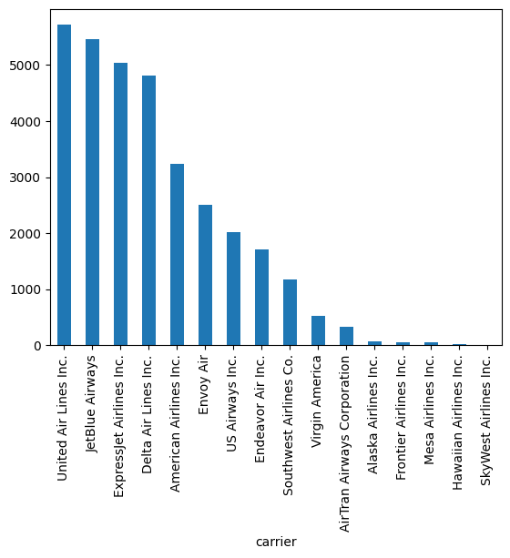

```python
df_flights['carrier'].value_counts().plot(kind='bar')
```

But this is hard to read. No problem, we can flip axes easily.

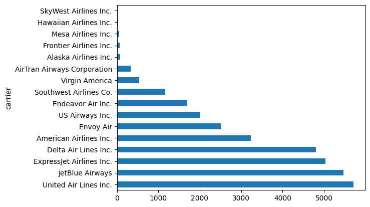

```python
df_flights['carrier'].value_counts().plot(kind='barh')
```

But why is the smalles count on top. It makes sense to show them in descending order, from the top to bottom.

```python
df_flights['carrier'].value_counts(ascending=True)
```

```
carrier
SkyWest Airlines Inc.             2
Hawaiian Airlines Inc.           28
Mesa Airlines Inc.               49
Frontier Airlines Inc.           59
Alaska Airlines Inc.             76
AirTran Airways Corporation     331
Virgin America                  531
Southwest Airlines Co.         1169
Endeavor Air Inc.              1702
US Airways Inc.                2011
Envoy Air                      2509
American Airlines Inc.         3230
Delta Air Lines Inc.           4811
ExpressJet Airlines Inc.       5032
JetBlue Airways                5466
United Air Lines Inc.          5714
Name: count, dtype: int64
```

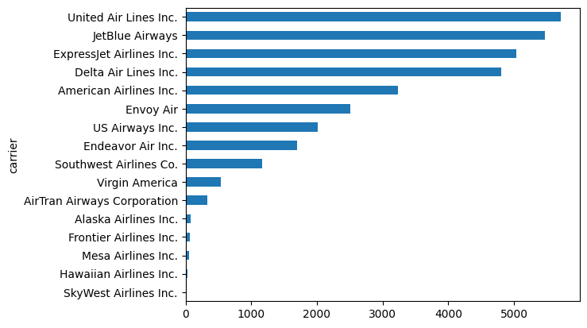

```python
df_flights['carrier'].value_counts(ascending=True).plot(kind='barh')
```

But this doesn't make sense, right? Well it does. First value in the Series returned is the one that gets mapped to the smallest value of Y axis. Remember, we are plotting in corrdinate space.

And now you take this and want to present to someone, and he or she doesn't know what he is looking at, right? Where is the title, what is displayed on X and Y axes?

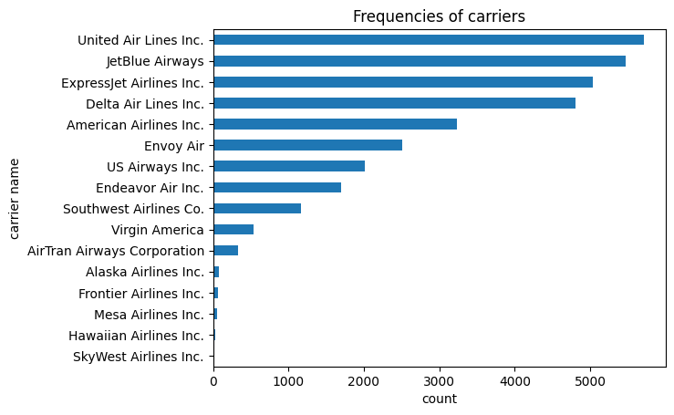

```python
df_flights['carrier'].value_counts(ascending=True).plot(kind='barh')
plt.title('Frequencies of carriers')
plt.xlabel('count')
plt.ylabel('carrier name')
```

What about we want to see what is the average air time for carrier? How can we do that?

What about we do that for most frequent carrier, United Air Lines Inc.?

```python
df_flights.loc[df_flights['carrier'] == 'United Air Lines Inc.', 'air_time'].describe()
```

```
count    5714.000000
mean      211.846867
std       101.008854
min        30.000000
25%       134.000000
50%       198.000000
75%       314.000000
max       667.000000
Name: air_time, dtype: float64
```

How can we do this and display it at the same time?

There is something called `boxplot`. Here is how it looks like:

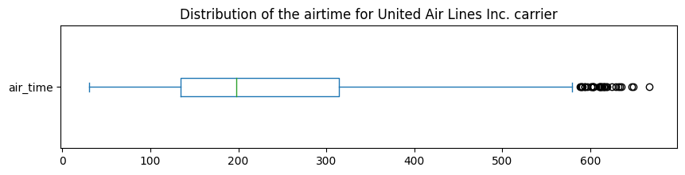

```python
plt.figure(figsize=(10, 2))
df_flights.loc[df_flights['carrier'] == 'United Air Lines Inc.', 'air_time'].plot(kind='box', vert=False)
plt.title('Distribution of the airtime for United Air Lines Inc. carrier')
```

Distribution... what is the distribution?

But we have one more type of chart that can show us exactly how distribution looks like. It is called `histogram`.

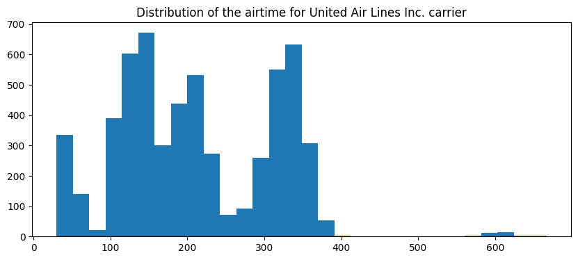

```python
plt.figure(figsize=(10, 4))
df_flights.loc[df_flights['carrier'] == 'United Air Lines Inc.', 'air_time'].hist(bins=30)
plt.grid(False)
plt.title('Distribution of the airtime for United Air Lines Inc. carrier')
```

This gives new perspective on your data, right? Cool.

```python
df_flights.head(n=5)
```

|  | Unnamed: 0 | year | month | day | dep_time | sched_dep_time | dep_delay | arr_time | sched_arr_time | arr_delay | ... | flight | tailnum | origin | dest | air_time | distance | hour | minute | time_hour | air_time_hours |
| --- | --- | --- | --- | --- | --- | --- | --- | --- | --- | --- | --- | --- | --- | --- | --- | --- | --- | --- | --- | --- | --- |
| 23583 | 23583 | 2013 | 1 | 28 | 858.0 | 905 | -7.0 | 1004.0 | 1023 | -19.0 | ... | 56 | N323JB | John F Kennedy Intl | Burlington Intl | 48.0 | 266 | 9 | 5 | 2013-01-28 09:00:00 | 0 |
| 39402 | 39402 | 2013 | 10 | 14 | 1138.0 | 1130 | 8.0 | 1334.0 | 1338 | -4.0 | ... | 4445 | N21197 | Newark Liberty Intl | Indianapolis Intl | 94.0 | 645 | 11 | 30 | 2013-10-14 11:00:00 | 1 |
| 9240 | 9240 | 2013 | 1 | 11 | 1248.0 | 1300 | -12.0 | 1438.0 | 1450 | -12.0 | ... | 4426 | N713MQ | La Guardia | Port Columbus Intl | 83.0 | 479 | 13 | 0 | 2013-01-11 13:00:00 | 1 |
| 231428 | 231428 | 2013 | 6 | 11 | 557.0 | 605 | -8.0 | 731.0 | 749 | -18.0 | ... | 1279 | N358NB | La Guardia | Memphis Intl | 131.0 | 963 | 6 | 5 | 2013-06-11 06:00:00 | 2 |
| 88913 | 88913 | 2013 | 12 | 6 | 2115.0 | 2115 | 0.0 | 2340.0 | 2315 | 25.0 | ... | 3384 | N531MQ | La Guardia | Charlotte Douglas Intl | 93.0 | 544 | 21 | 15 | 2013-12-06 21:00:00 | 1 |

5 rows × 21 columns

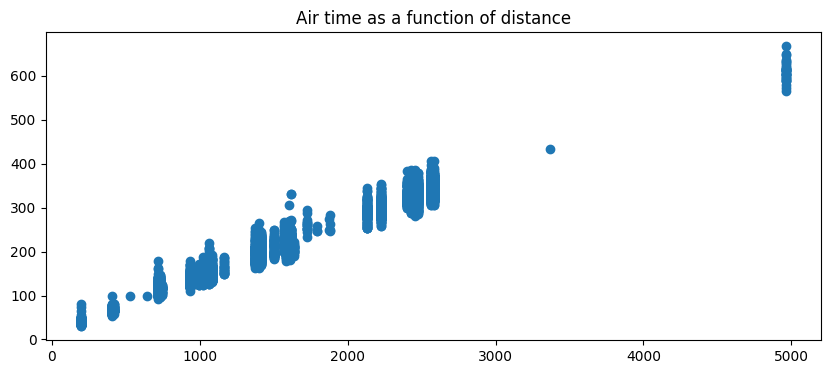

```python
plt.figure(figsize=(10, 4))
plt.scatter(x='distance', y='air_time', data=df_flights.loc[df_flights['carrier'] == 'United Air Lines Inc.'])
plt.title('Air time as a function of distance')
```

There is much more charts and ways to visualize your data, and this step is really important in machine learning and data science in general. Without understanding your data you can never start modeling.

## NumPy basics

NumPy, short for Numerical Python, is a powerful open-source library for numerical computing in Python. It provides essential functionality for efficiently working with large, multi-dimensional arrays and matrices, along with a wide range of mathematical functions to operate on these arrays. NumPy serves as the foundation for numerous scientific and data-related libraries in the Python ecosystem, making it a fundamental tool for data scientists, engineers, and researchers.

We have already mentioned that NumPy is integrated in Pandas. Well, until the last version that is. Future versions of Pandas will head toward breaking ties with NumPy.

Here and now, we are going to take a peek into NumPy and see how it is tied to Pandas.

Remember our test DataFrames.

### Pandas to Numpy

```python
df_test5
```

|  | rank | name | grade | rank_transform | name_caps |
| --- | --- | --- | --- | --- | --- |
| 0 | 1 | marko | 2.15 | 6 | MARKO |
| 1 | 3 | nikola | 1.00 | 8 | NIKOLA |
| 2 | 4 | jovana | 2.50 | 9 | JOVANA |
| 4 | 5 | dragana | 2.25 | 10 | DRAGANA |

```python
df_test5.loc[:, 'grade']
```

```
0    2.15
1    1.00
2    2.50
4    2.25
Name: grade, dtype: float64
```

```python
df_test5['grade']
```

```
0    2.15
1    1.00
2    2.50
4    2.25
Name: grade, dtype: float64
```

```python
df_test5['grade'].values
```

```
array([2.15, 1.  , 2.5 , 2.25])
```

### Basic NumPy array creation

`array([...])` is the sign of Pandas having NumPy arrays below the surface. Here we asked for raw values of our Series and we got NumPy array.

Let's start with creating NumPy and some basic operation with NumPy arrays.

```python
arr_test1 = np.array([1,2,3,4,5])

arr_test1
```

```
array([1, 2, 3, 4, 5])
```

We create NumPy array by providing Python list. It is then converted into NumPy array with same elements and same size.

```python
arr_test1.shape
```

```
(5,)
```

```python
len(arr_test1)
```

```
5
```

Similar to Python and Pandas DataFrame. You get the length of the array.

```python
type(arr_test1)
```

```
numpy.ndarray
```

That's it. NumPy array.

Why are NumPy arrays important?

Well, NumPy arrays provide one important feature and that is speed. These arrays contain only elements of the same data type, and therefore their memmory footprint is smaller and it is easier to work with them.

If you know Python you know that you can end up with next scenario:

```python
_list = [1, "sas", 4.4]
```

And this is perfectly okay... in Python. Not in NumPy. Because of this, you can always be sure that you will be able to run functions and methods on these arrays without any issue.

### Basic NumPy arrays arithmetic

```python
arr_test1
```

```
array([1, 2, 3, 4, 5])
```

```python
arr_test1 * 3
```

```
array([ 3,  6,  9, 12, 15])
```

```python
arr_test1 / 3
```

```
array([0.33333333, 0.66666667, 1.        , 1.33333333, 1.66666667])
```

```python
arr_test1 ** 2
```

```
array([ 1,  4,  9, 16, 25])
```

How about so called 'element-wise' operations?

```python
arr_test1 + arr_test1
```

```
array([ 2,  4,  6,  8, 10])
```

```python
arr_test1 * arr_test1
```

```
array([ 1,  4,  9, 16, 25])
```

You probably get the idea why it is called 'element-wise'? Because we perform arrays operation so that corresponding elements get summed, or multiplied.

You can do this too:

```python
arr_test1 ** arr_test1
```

```
array([   1,    4,   27,  256, 3125])
```

You can even test on logical conditions:

```python
arr_test1 > 3
```

```
array([False, False, False,  True,  True])
```

And the result will be NumPy array. And what happens if you do next:

```python
arr_test1[arr_test1 > 3]
```

```
array([4, 5])
```

Or how about this:

```python
arr_test1[arr_test1 > 3].sum()
```

```
9
```

Interesting things can be achieved with NumPy. And some of these look similar to what we did in Pandas.

```python
# refresher
arr_test1
```

```
array([1, 2, 3, 4, 5])
```

How about we get `mean`, `median` and `std` for our array?

```python
np.mean(arr_test1), np.median(arr_test1), np.std(arr_test1)
```

```
(3.0, 3.0, 1.4142135623730951)
```

There is a lot more NumPy functions that you can use. Here are some interesting ones.

```python
np.zeros(shape=(5, ))
```

```
array([0., 0., 0., 0., 0.])
```

```python
np.ones(shape=(5, ))
```

```
array([1., 1., 1., 1., 1.])
```

```python
np.repeat(4, repeats=5)
```

```
array([4, 4, 4, 4, 4])
```

```python
np.arange(start=0, stop=10, step=2)
```

```
array([0, 2, 4, 6, 8])
```

Or, you can use different approach in getting the list of numbers:

```python
np.linspace(start=0, stop=10, num=11)
```

```
array([ 0.,  1.,  2.,  3.,  4.,  5.,  6.,  7.,  8.,  9., 10.])
```

Maybe all you need is vector of random numbers?

```python
arr_test2 = np.random.randint(low=0, high=10, size=10)

arr_test2
```

```
array([9, 2, 4, 1, 5, 5, 7, 3, 4, 0])
```

### NumPy matrices

And now, let's introduce matrices:

```python
mat_test1 = np.array([
    [1,2,3], [5,6,7]
])
```

```python
mat_test1
```

```
array([[1, 2, 3],
       [5, 6, 7]])
```

How about we want to transpose our matrix? Do you remember what transposing means? It's making rows columns and column rows. Look:

```python
mat_test1.T
```

```
array([[1, 5],
       [2, 6],
       [3, 7]])
```

We can use `np.ones`, `np.zeros` to create matrices of different dimensions. Here is the example:

```python
np.ones(shape=(3, 2)) # 3 rows, 2 columns
```

```
array([[1., 1.],
       [1., 1.],
       [1., 1.]])
```

```python
np.zeros(shape=3)
```

```
array([0., 0., 0.])
```

And how can we sum matrices?

```python
mat_test1 + np.ones(shape=mat_test1.shape)
```

```
array([[2., 3., 4.],
       [6., 7., 8.]])
```

And what about we sum matrix with vector? Is this mathematically valid?

```python
np.ones(shape=(2, 1))
```

```
array([[1.],
       [1.]])
```

```python
mat_test1
```

```
array([[1, 2, 3],
       [5, 6, 7]])
```

```python
mat_test1 + np.ones(shape=(2, 1))
```

```
array([[2., 3., 4.],
       [6., 7., 8.]])
```

Hold on, how is this possible? It is possible due to broadcasting. It's good to know that it exists, but we will not go into describing all the details. Just to say, be careful.

How about we fiddle with matrices and vectors.

Did you know you can create matrix by using vector, and vice versa?

```python
mat_test1
```

```
array([[1, 2, 3],
       [5, 6, 7]])
```

```python
mat_test1.flatten()
```

```
array([1, 2, 3, 5, 6, 7])
```

```python
mat_test1.reshape(1, -1)
```

```
array([[1, 2, 3, 5, 6, 7]])
```

This reshapes your NumPy array so that it **certainly have 1 row**, while NumPy should deal with number of columns.

How about we reshape it back, but not in the same shape?

```python
arr_test2
```

```
array([9, 2, 4, 1, 5, 5, 7, 3, 4, 0])
```

```python
arr_test2.reshape(5, -1)
```

```
array([[9, 2],
       [4, 1],
       [5, 5],
       [7, 3],
       [4, 0]])
```

This required that the resulting NumPy array contains exactly 5 rows, and the rest is up to NumPy to figure out. We can be explicit as well:

```python
arr_test2.reshape(5, 2)
```

```
array([[9, 2],
       [4, 1],
       [5, 5],
       [7, 3],
       [4, 0]])
```

Works like a charm.

And now, how about we want to select specific rows and columns in matrix?

### NumPy slicing

```python
mat_test1
```

```
array([[1, 2, 3],
       [5, 6, 7]])
```

```python
mat_test1[:, 2] # third column
```

```
array([3, 7])
```

```python
mat_test1[1, :] # second row... indexing starts from 0
```

```
array([5, 6, 7])
```

```python
mat_test1[0, 2] # first row, third column
```

```
3
```

We can do some Pythonic slicing too:

```python
arr_test2
```

```
array([9, 2, 4, 1, 5, 5, 7, 3, 4, 0])
```

```python
arr_test2[:3] # slice until forth element
```

```
array([9, 2, 4])
```

```python
arr_test2[5:] # slice from sixth element
```

```
array([5, 7, 3, 4, 0])
```

```python
arr_test2[5: -2] # slice from sixth element until third from the back
```

```
array([5, 7, 3])
```

```python
arr_test2[::2] # take every second element starting from the beginning
```

```
array([9, 4, 5, 7, 4])
```

Combinations are endless and so is the fun with NumPy.

### Basic NumPy algebra

And the last thing we want to show you is... maths. Linear algebra and some really simple functions with matrices and vectors.

We already saw that we can multiply vector or matrix with scalar:

```python
mat_test1
```

```
array([[1, 2, 3],
       [5, 6, 7]])
```

```python
mat_test1 * 2
```

```
array([[ 2,  4,  6],
       [10, 12, 14]])
```

We saw that multiplying matrix with vector is possible:

```python
mat_test1 * np.array([5,6,7])
```

```
array([[ 5, 12, 21],
       [25, 36, 49]])
```

This is the same as:

```python
np.multiply(mat_test1, np.array([5,6,7]))
```

```
array([[ 5, 12, 21],
       [25, 36, 49]])
```

But what about **dot product** of two vectors?

```python
arr_test1
```

```
array([1, 2, 3, 4, 5])
```

```python
_res = 0
for i in arr_test1:
    _res += i * i

_res
```

```
55
```

Or we can do it like this:

```python
np.dot(arr_test1, arr_test1)
```

```
55
```

And this:

```python
arr_test1 @ arr_test1
```

```
55
```

And what about we take matrix and do the dot product with a vector:

```python
mat_test2 = np.random.randint(low=0, high=10, size=6).reshape(2, -2)

mat_test2
```

```
array([[0, 2, 8],
       [8, 4, 6]])
```

```python
mat_test2.shape
```

```
(2, 3)
```

```python
arr_test1
```

```
array([1, 2, 3, 4, 5])
```

```python
# this will not work, why?
# mat_test2 @ arr_test1
```

```python
arr_test1[:3]
```

```
array([1, 2, 3])
```

```python
mat_test2 @ arr_test1[:3]
```

```
array([28, 34])
```

We have just scratched the surface of Pandas and NumPy, but this is quite enough for you to get familiar whith the libraries and start exploring for yourself.